# Coursera: Practical Machine Learning - Course Project

Sreenivasulu Parimi

June 22, 2018

# Creating a prediction model

## Overview

Using devices such as Jawbone Up, Nike FuelBand, and Fitbit it is now possible to collect a large amount of data about personal activity relatively inexpensively. These type of devices are part of the quantified self movement, a group of enthusiasts who take measurements about themselves regularly to improve their health, to find patterns in their behavior, or because they are tech geeks. One thing that people regularly do is quantify how much of a particular activity they do, but they rarely quantify how well they do it. In this project, your goal will be to use data from accelerometers on the belt, forearm, arm, and dumbell of 6 participants. They were asked to perform barbell lifts correctly and incorrectly in 5 different ways. More information is available from the website here: http://web.archive.org/web/20161224072740/http:/groupware.les.inf.puc-rio.br/har.

The goal of this project is to build a machine learning algorithm to predict activity quality (classe) from activity monitors.

#### Course Project Prediction Quiz Portion

Apply your machine learning algorithm to the 20 test cases available in the test data above and submit your predictions in appropriate format to the Course Project Prediction Quiz for automated grading.

## Load Required Libraries

```r
library(caret)
```

```r
library(ggplot2)
```

## Download the Data

```r
train_url <- "http://d396qusza40orc.cloudfront.net/predmachlearn/pml-training.csv"
validation_url <- "http://d396qusza40orc.cloudfront.net/predmachlearn/pml-testing.csv"

# Download the data into current working directory:
train_file <- "./data/pml-training.csv"
validation_file  <- "./data/pml-testing.csv"

if(!file.exists("./data")) {
      dir.create("./data")
}

if(!file.exists(train_file)) {
      download.file(train_url, destfile=train_file, method="curl")
}

if(!file.exists(validation_file)) {
      download.file(validation_url, destfile=validation_file, method="curl")
}
```

## Read the Data

```r
train <- read.csv("./data/pml-training.csv")
validation <- read.csv("./data/pml-testing.csv")
```

## Data Exploration and Preprocessing

```r
dim(train)
```

```
## [1] 19622   160
```

```r
dim(validation)
```

```
## [1]  20 160
```

```r
str(train)
```

```
## 'data.frame':    19622 obs. of  160 variables:
##  $ X                       : int  1 2 3 4 5 6 7 8 9 10 ...
##  $ user_name               : Factor w/ 6 levels "adelmo","carlitos",..: 2 2 2 2 2 2 2 2 2 2 ...
##  $ raw_timestamp_part_1    : int  1323084231 1323084231 1323084231 1323084232 1323084232 1323084232 1323084232 1323084232 1323084232 1323084232 ...
##  $ raw_timestamp_part_2    : int  788290 808298 820366 120339 196328 304277 368296 440390 484323 484434 ...
##  $ cvtd_timestamp          : Factor w/ 20 levels "02/12/2011 13:32",..: 9 9 9 9 9 9 9 9 9 9 ...
##  $ new_window              : Factor w/ 2 levels "no","yes": 1 1 1 1 1 1 1 1 1 1 ...
##  $ num_window              : int  11 11 11 12 12 12 12 12 12 12 ...
##  $ roll_belt               : num  1.41 1.41 1.42 1.48 1.48 1.45 1.42 1.42 1.43 1.45 ...
##  $ pitch_belt              : num  8.07 8.07 8.07 8.05 8.07 8.06 8.09 8.13 8.16 8.17 ...
##  $ yaw_belt                : num  -94.4 -94.4 -94.4 -94.4 -94.4 -94.4 -94.4 -94.4 -94.4 -94.4 ...
##  $ total_accel_belt        : int  3 3 3 3 3 3 3 3 3 3 ...
##  $ kurtosis_roll_belt      : Factor w/ 397 levels "","-0.016850",..: 1 1 1 1 1 1 1 1 1 1 ...
##  $ kurtosis_picth_belt     : Factor w/ 317 levels "","-0.021887",..: 1 1 1 1 1 1 1 1 1 1 ...
##  $ kurtosis_yaw_belt       : Factor w/ 2 levels "","#DIV/0!": 1 1 1 1 1 1 1 1 1 1 ...
```

[output cut: 86 more lines]

The training data has 19622 observations and 160 variables whereas has 20 observations and 160 variables.

From the above, we can observe that first few (7) variables called **x** contains row numbers; **user_name** contains user name who did the test; **raw_timestamp_part_1**, **raw_timestamp_part_2**, and **cvtd_timestamp** are contain timestamps; **new_window** and **num_window** are not related to sensor data. So, we can ignore these variables since they don’t add any value to the prediction outcome.

```r
train_NAs <- colMeans(is.na(train))
table(train_NAs)
```

```
## train_NAs
##                 0 0.979308938946081
##                93                67
```

```r
validation_NAs <- colMeans(is.na(validation))
table(validation_NAs)
```

```
## validation_NAs
##   0   1
##  60 100
```

From the above, we can notice that there are 67 variables in which almost all values (97.93%) are missing. Therefore, we can remove these variable as well since they don’t add any additionval value to the outcome class.

### Feature selection

Now we can tranform the data to only include the variables we will need to build our model. We will remove variables with near zero variance, variables with mostly missing data, and variables that are obviously not useful as predictors.

**Remove the first 7 variables**:

```r
# remove variables that don't make intuitive sense for prediction
train_tidy <- train[,-c(1:7)]
validation_tidy <- validation[,-c(1:7)]
dim(train_tidy)
```

```
## [1] 19622   153
```

```r
dim(validation_tidy)
```

```
## [1]  20 153
```

**Remove the NearZeroVariance variables**:

```r
# remove variables with nearly zero variance
nzv <- nearZeroVar(train_tidy, saveMetrics=TRUE)
train_tidy <- train_tidy[,nzv$nzv==FALSE]

nzv<- nearZeroVar(validation_tidy,saveMetrics=TRUE)
validation_tidy <- validation_tidy[,nzv$nzv==FALSE]

dim(train_tidy)
```

```
## [1] 19622    94
```

```r
dim(validation_tidy)
```

```
## [1] 20 53
```

**Remove the variables those are all most NAs**:

```r
# remove variables that are almost NA
# Here we get the indexes of the columns having at least 90% of NA or blank values on the training dataset
train_NAs <- sapply(train_tidy, function(x) mean(is.na(x))) > 0.95
validation_NAs <- sapply(validation_tidy, function(x) mean(is.na(x))) > 0.95
train_tidy <- train_tidy[, train_NAs==FALSE]
validation_tidy  <- validation_tidy[, validation_NAs==FALSE]
validation_tidy  <- validation_tidy[, -length(validation_tidy)] #Remove problem_id

dim(train_tidy)
```

```
## [1] 19622    53
```

```r
dim(validation_tidy)
```

```
## [1] 20 52
```

## Build Model

In order to pick best fit model on the given data, we perform 3 different models **Classification Tree**, **Random Forest** and **gradient boosting** in the following sections.

#### Split the Data to training and testing

Partioning the cleaned training set into train and test.

```r
set.seed(45)
inTrain <- createDataPartition(train_tidy$classe, p=0.70, list=FALSE)
train_data <- train_tidy[inTrain,]
test_data <- train_tidy[-inTrain,]
dim(train_data)
```

```
## [1] 13737    53
```

```r
dim(test_data)
```

```
## [1] 5885   53
```

#### Cross Validation

Cross validation method can be used to limit the effects of overfitting and improve the efficiency of the models. Useally, this method uses 5 or 10 folds. But, 10 folds take more run time with no significant increase of the accuracy. So, we can use 5 fold.

```r
# instruct train to use 5-fold CV to select optimal tuning parameters
fitControl <- trainControl(method="cv", number=5)
```

### Classification Tree (Decision Trees)

```r
# Classification Tree Fit
fit_cf<- train(classe ~ ., data=train_data, method="rpart", trControl=fitControl)

# use model to predict classe in test_data
cf_pred <- predict(fit_cf, newdata=test_data)

# show confusion matrix to get estimate of out-of-sample error
confusionMatrix(test_data$classe, cf_pred)
```

```
## Confusion Matrix and Statistics
##
##           Reference
## Prediction    A    B    C    D    E
##          A 1521   14  134    0    5
##          B  478  363  298    0    0
##          C  468   31  527    0    0
##          D  412  183  369    0    0
##          E  150  135  295    0  502
##
## Overall Statistics
##
##                Accuracy : 0.495
##                  95% CI : (0.4821, 0.5078)
##     No Information Rate : 0.5147
##     P-Value [Acc > NIR] : 0.9988
##
##                   Kappa : 0.3405
##  Mcnemar's Test P-Value : NA
##
## Statistics by Class:
##
##                      Class: A Class: B Class: C Class: D Class: E
## Sensitivity            0.5021  0.50000  0.32471       NA  0.99014
## Specificity            0.9464  0.84958  0.88292   0.8362  0.89215
## Pos Pred Value         0.9086  0.31870  0.51365       NA  0.46396
## Neg Pred Value         0.6419  0.92351  0.77444       NA  0.99896
## Prevalence             0.5147  0.12336  0.27579   0.0000  0.08615
## Detection Rate         0.2585  0.06168  0.08955   0.0000  0.08530
## Detection Prevalence   0.2845  0.19354  0.17434   0.1638  0.18386
## Balanced Accuracy      0.7243  0.67479  0.60381       NA  0.94115
```

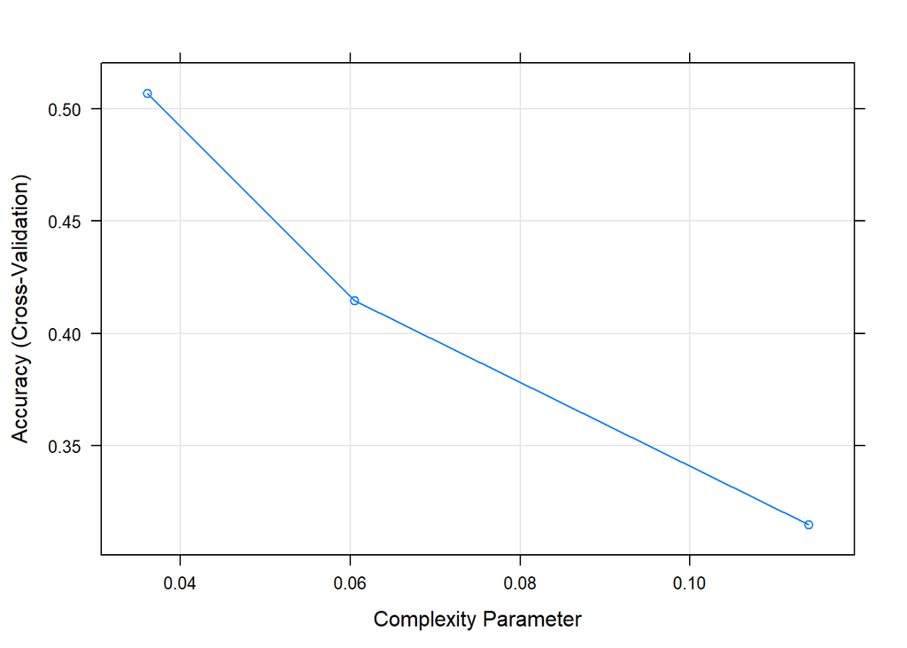

```r
plot(fit_cf)
```

### Random Forests

```r
# Random Forest Model Fit
fit_rf<- train(classe ~ ., data=train_data, method="rf", trControl=fitControl)

# use model to predict classe in in test_data
rf_pred <- predict(fit_rf, newdata=test_data)

# show confusion matrix to get estimate of out-of-sample error
confusionMatrix(test_data$classe, rf_pred)
```

```
## Confusion Matrix and Statistics
##
##           Reference
## Prediction    A    B    C    D    E
##          A 1670    3    0    0    1
##          B    6 1131    2    0    0
##          C    0    8 1018    0    0
##          D    0    0   17  945    2
##          E    0    0    0    6 1076
##
## Overall Statistics
##
##                Accuracy : 0.9924
##                  95% CI : (0.9898, 0.9944)
##     No Information Rate : 0.2848
##     P-Value [Acc > NIR] : < 2.2e-16
##
##                   Kappa : 0.9903
##  Mcnemar's Test P-Value : NA
##
## Statistics by Class:
##
##                      Class: A Class: B Class: C Class: D Class: E
## Sensitivity            0.9964   0.9904   0.9817   0.9937   0.9972
## Specificity            0.9990   0.9983   0.9983   0.9961   0.9988
## Pos Pred Value         0.9976   0.9930   0.9922   0.9803   0.9945
## Neg Pred Value         0.9986   0.9977   0.9961   0.9988   0.9994
## Prevalence             0.2848   0.1941   0.1762   0.1616   0.1833
## Detection Rate         0.2838   0.1922   0.1730   0.1606   0.1828
## Detection Prevalence   0.2845   0.1935   0.1743   0.1638   0.1839
## Balanced Accuracy      0.9977   0.9943   0.9900   0.9949   0.9980
```

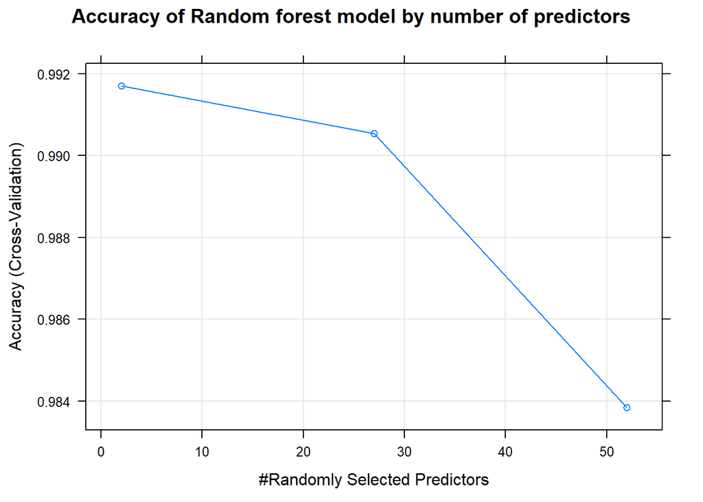

```r
plot(fit_rf,main="Accuracy of Random forest model by number of predictors")
```

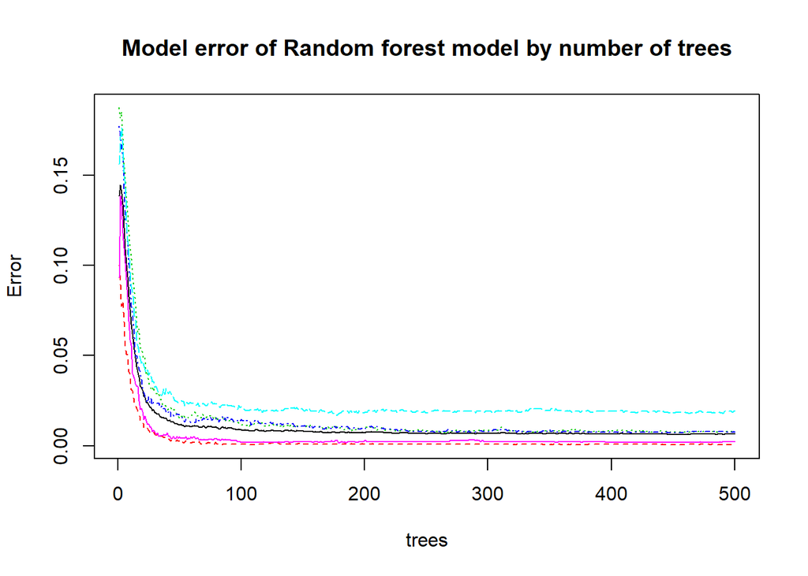

```r
plot(fit_rf$finalModel,main="Model error of Random forest model by number of trees")
```

```r
# variable importance
varImp(fit_rf)
```

```
## rf variable importance
##
##   only 20 most important variables shown (out of 52)
##
##                   Overall
## roll_belt          100.00
## yaw_belt            81.21
## magnet_dumbbell_z   73.80
## magnet_dumbbell_y   66.20
## pitch_belt          63.42
## pitch_forearm       62.66
## magnet_dumbbell_x   56.94
## roll_forearm        54.51
## accel_dumbbell_y    48.72
## accel_belt_z        47.73
## magnet_belt_z       46.69
## roll_dumbbell       45.88
## magnet_belt_y       43.42
## accel_dumbbell_z    40.22
## roll_arm            35.40
## accel_forearm_x     34.55
## gyros_belt_z        34.34
## yaw_dumbbell        31.42
## accel_dumbbell_x    30.60
## magnet_arm_x        30.03
```

### Gradient Boosting

```r
# Gradient Boosting Model Fit
fit_gb <- train(classe ~ ., data=train_data, method="gbm", trControl=fitControl, verbose=FALSE)

# use model to predict classe in in test_data
gb_pred <- predict(fit_gb, newdata=test_data)

# show confusion matrix to get estimate of out-of-sample error
confusionMatrix(test_data$classe, gb_pred)
```

```
## Confusion Matrix and Statistics
##
##           Reference
## Prediction    A    B    C    D    E
##          A 1649   17    8    0    0
##          B   31 1078   28    1    1
##          C    0   27  990    7    2
##          D    2    5   38  912    7
##          E    0   11    7   20 1044
##
## Overall Statistics
##
##                Accuracy : 0.964
##                  95% CI : (0.9589, 0.9686)
##     No Information Rate : 0.2858
##     P-Value [Acc > NIR] : < 2.2e-16
##
##                   Kappa : 0.9544
##  Mcnemar's Test P-Value : NA
##
## Statistics by Class:
##
##                      Class: A Class: B Class: C Class: D Class: E
## Sensitivity            0.9804   0.9473   0.9244   0.9702   0.9905
## Specificity            0.9941   0.9871   0.9925   0.9895   0.9921
## Pos Pred Value         0.9851   0.9464   0.9649   0.9461   0.9649
## Neg Pred Value         0.9922   0.9874   0.9833   0.9943   0.9979
## Prevalence             0.2858   0.1934   0.1820   0.1597   0.1791
## Detection Rate         0.2802   0.1832   0.1682   0.1550   0.1774
## Detection Prevalence   0.2845   0.1935   0.1743   0.1638   0.1839
## Balanced Accuracy      0.9872   0.9672   0.9584   0.9798   0.9913
```

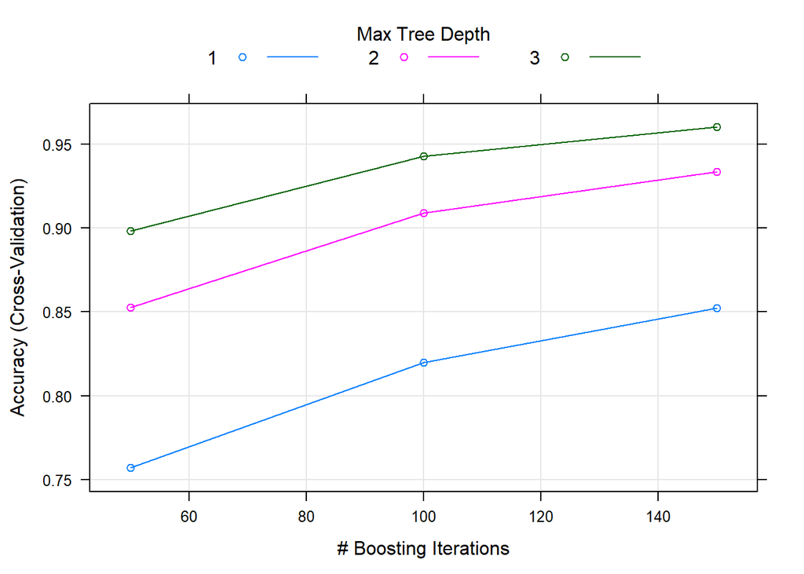

```r
plot(fit_gb)
```

### Best Model

From the above 3 models, we can notice that Random Forest gives best accuracy 99.24%. Acutally, the **train_data** contains only 70% of original training data. In order to produce the most accurate predictions, we can train the best model i.e random forest on the full training data **train_tidy data**.

```r
# Random Forest Model Fit on full training data
fit_best <- train(classe ~ ., data=train_tidy, method="rf", trControl=fitControl)
```

## Submission

Now we can use the best fitted model **fit_best** to prict the **classe** on the given actual test data.

```r
validation_pred <- predict(fit_best, newdata=validation_tidy)
```

The following function generates a file with predictions to submit as answers for the assignment.

```r
pml_write_files = function(x) {
      n = length(x)
      for(i in 1:n) {
            filename = paste0("problem_id_",i,".txt")
            write.table(x[i],file=filename,quote=FALSE,row.names=FALSE,col.names=FALSE)
      }
}
pml_write_files(validation_pred)
validation_pred
```

```
##  [1] B A B A A E D B A A B C B A E E A B B B
## Levels: A B C D E
```